# Bayesian design and analysis of external pilot trials for complex interventions

July 17, 2019

## External pilot trials

\(\{\text{Pilot trials}\} \subset \{\text{Feasibility studies}\}\) (Eldridge et al., 2016)

A small version of the planned main study.

Asking the questions: *should* we do the main trial, and if so, *how*?

Common quantitative objectives: estimating recruitment rates, follow-up rates, and adherence rates (Avery et al., 2017).

## Example - REACH

REACH (Research Exploring Physical Activity in Care Homes): a pilot for a complex intervention designed to increase the physical activity of care home residents.

Feasibility outcomes:

- **Recruitment** (measured in terms of the average number of residents in each care home who participate in the trial);
- **Adherence** (a binary indicator at the care home level indicating if the intervention was fully implemented);
- **Follow-up** (a binary indicator for each resident of successful follow-up at the planned primary outcome time of 12 months);
- **Efficacy** (a continuous measure of physical activity at the resident level).

## Example - REACH

Cluster randomised, with 6 care homes per arm.

Progressing to the definitive trial if the *progression criteria* are satisfied:

| Outcome | Red | Amber | GReen |
| --- | --- | --- | --- |
| Recruitment | Less than 8 | Between 8 and 10 | At least 10 |
| Follow-up | Less than 50% | Between 50 and 75% | At least 75% |
| Adherence | Less than 65% | Between 65 and 75% | At least 75% |

- Any *red* \(\Rightarrow\) stop
- All *green* \(\Rightarrow\) go
- Otherwise, modify and then go

## Motivation

Can we better formalise how to make decisions after pilot trials? Challenges:

- 3 decision options, stop / modify / go.
- Several attributes of interest, with trade-offs between them.
- Complex, small sample models with uncertain nuisance parameters (e.g. an ICC)

\(\rightarrow\) Bayesian approach

Questions:

- How should we make progression decisions after a Bayesain analysis?
- How can we evaluate a Bayesain pilot design and choose its sample size?

## Hypotheses

Identify areas of the parameter space where we would ideally like to *stop* (R), *modify* (A), or *go* (G):

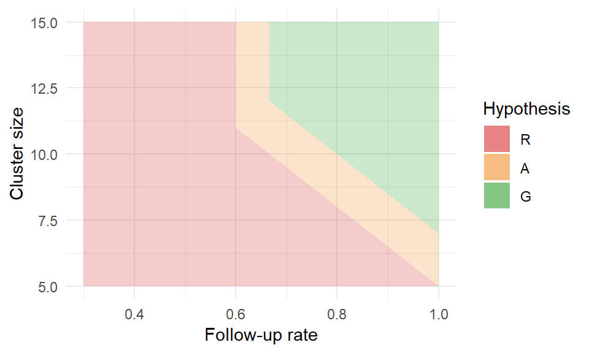

## Loss

Three types of errors:

- \(E_1\): proceeding to a futile trial
- \(E_2\): discarding a promising intervention
- \(E_3\): needlessly modifying the intervention or trial design

The loss depeneds on which errors occur, which depends on the decision \(d\) and the hypothesis which \(\phi\) lies in.

\[ L(d, \phi) = c_1 E_1(d, \phi) + c_2 E_2(d, \phi) + c_3 E_3(d, \phi). \] 3 descisions and 3 hypotheses \(\Rightarrow\) 9 possible loss outcomes:

| Decision | \(\phi \in \Phi_R\) | \(\phi \in \Phi_A\) | \(\phi \in \Phi_G\) |
| --- | --- | --- | --- |
| \(r\) | 0 | \(c_2\) | \(c_2\) |
| \(a\) | \(c_1 + c_3\) | 0 | \(c_3\) |
| \(g\) | \(c_1\) | \(c_1 + c_2\) | 0 |

## Expected loss

After seeing the pilot data \(x\), we choose the action with the best expected loss:

## Operating characteristics and optimisation

Define three pilot trial operating characteristics:

- \(OC_1(\mathbf{c})\): probability of proceeding to an infeasible RCT
- \(OC_2(\mathbf{c})\): probability of discarding a promising intervention
- \(OC_3(\mathbf{c})\): probability of making unnecessary adjustments to the intervention or the trial design

We want to find costs \((\mathbf{c})\) which minimise these three conflicting objectibes.

Solve the multi-objective optimisation problem \[ \min_{\mathbf{c} \in \mathcal{C}} ~ \left( OC_{1}(\mathbf{c}),~ OC_{2}(\mathbf{c}),~ OC_{3}(\mathbf{c}) \right) \] where \(\mathcal{C} = \{c_{1}, c_{2} \in [0,1] ~|~ c_{1} + c_{2} \leq 1\}\).

\(\rightarrow\) a set of options for the cost parameters, offering different trade-offs between the three operating characteristics.

## Computation

A simple, but computationally expensive, nested Monte Carlo algorithm:

- **for** \(j = 1, 2, \ldots , N\) **do**
  - sample parameters \(\phi^{(j)} \sim p(\phi)\)
  - sample pilot data \(x \sim p(x \mid \phi)\)
  - **for** \(k = 1, 2, \ldots , M\) **do**
    - sample posterior \(\phi^{(k,j)} \sim p(\phi \mid x^{(j)})\)
  - estimate \(p_I^{(j)} \approx \frac{1}{M}\sum_{k=1}^{M} I[\phi^{(k,j)} \in \Phi_I]\) for \(I = R, A, G\)
  - get progression descision \(i^{(j)}\) based on \(\mathbf{c}\) and \(p_R^{(j)}, p_A^{(j)}, p_G^{(j)}\)
- estimate operating characteristics, e.g. \(OC_1(\mathbf{c}) \approx \frac{1}{N} \sum_{j=1}^{N} I[i^{(j)} = a ~\&~ \phi^{(j)} \in \Phi_R] + I[i^{(j)} = g ~\&~ \phi^{(j)} \in \Phi_R \cup \Phi_A]\)

(Note that when optimising over cost parameters \(\mathbf{c}\), we only need to generate one set of \(N\) posterior probability samples)

## Application

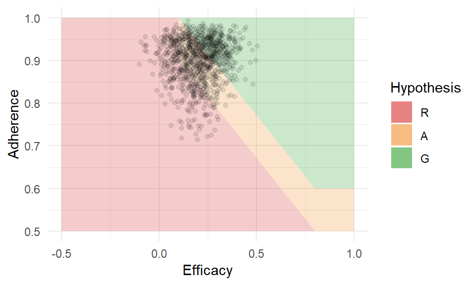

## Optimisation

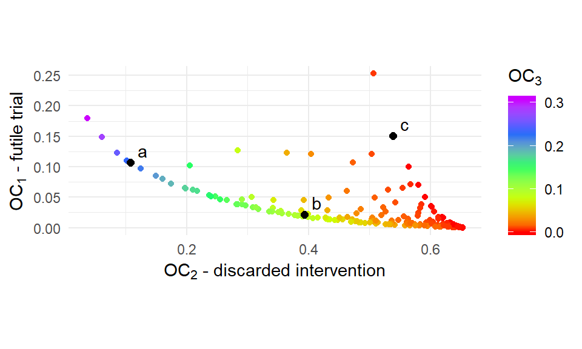

Because we have a 2-D space \(\mathcal{C} = \{c_{1}, c_{2} \in [0,1] ~|~ c_{1} + c_{2} \leq 1\}\), we do a simple grid search. Evaluating 254 cost parameters, 62 were found to be dominated in the Pareto sense.

## Example cost parameters

| Label | \((c_1, c_2, c_3)\) | \(OC_1\) | \(OC_2\) | \(OC_3\) |
| --- | --- | --- | --- | --- |
| a | (0.07, 0.9, 0.03) | 0.107 (0.003) | 0.108 (0.003) | 0.232 (0.004) |
| b | (0.18, 0.58, 0.24) | 0.021 (0.001) | 0.394 (0.005) | 0.08 (0.003) |
| c | (0.01, 0.29, 0.7) | 0.151 (0.004) | 0.539 (0.005) | 0.002 (0) |

## Sample size

For cost parameters \(c_1 = 0.07, c_2 = 0.9, c_3 = 0.03\) and pilot sample size of \(3, 6, 9\) per arm (bars indicate 95% CIs):

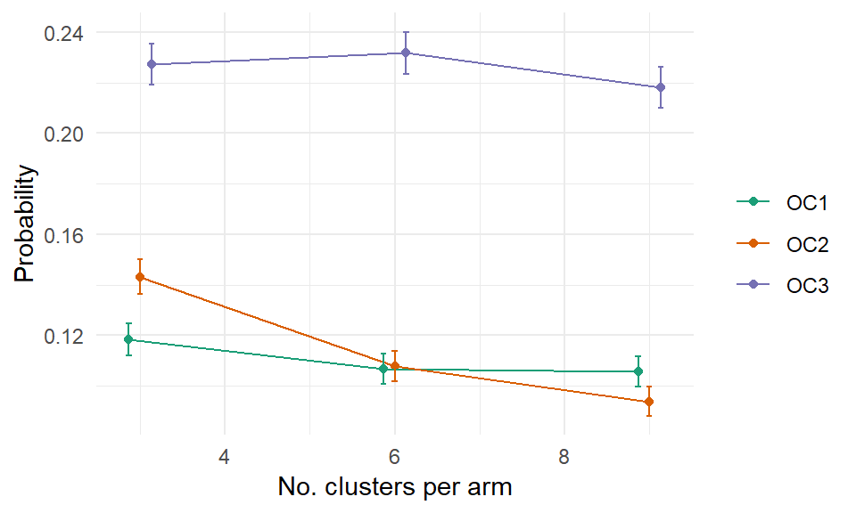

## Discussion

Implications:

Limitations:

- Need a lot of extra input from the people designing the trial - hypotheses and priors
- Computation is slow when out of a conjugate setting - makes sample size choice difficult to evaluate
- Pre-specifying an amber region might be difficult
- Piecewise constant loss function keeps things simple, but is unrealistic

## Thank you

### @DTWilson, D.T.Wilson@leeds.ac.uk, https://github.com/DTWilson/Bayesian_pilot